# FAQ

## Esercizio 3.3

Lo stesso principio si può applicare a qualsiasi test statistico come il `t-test` o lo `z-test`.

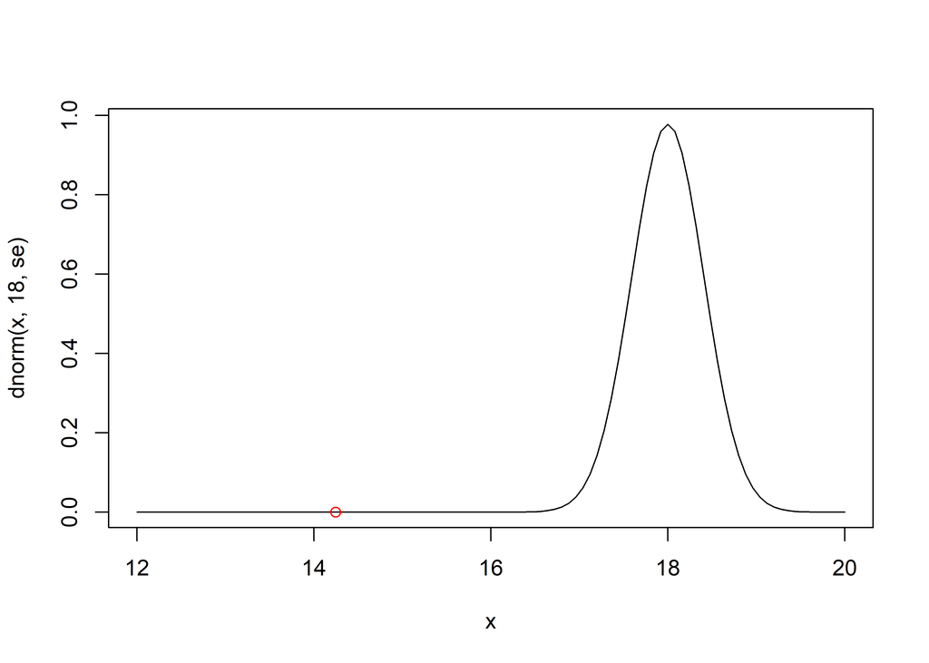

```r
esami <- scan("../data/esame.txt")

# calcolo media ed standard error
se <- sd(esami)/sqrt(length(esami))
mean_x <- mean(esami)

# distribuzione campionaria della media
curve(dnorm(x, 18, se), 12, 20)
points(mean_x, 0, col = "red")
```

A questo punto, posso calcolare la probabilità di ottenere un risultato minore o uguale a $\bar x$ usando la funzione `pnorm()` (esattamente come prima con `pbinom()`):

```r
pnorm(q = mean_x, mean = 18, sd = se)
```

```
## [1] 1.652358e-20
```

Come vedete è estremamente bassa, e ci suggerisce che il nostro risultato è altamente improbabile se la media vera da cui è stato estratto il nostro campione è 18.

Se vogliamo fare formalmente il nostro test, possiamo usare la funzione `t-test` (ad 1 campione):

```r
t.test(esami, mu = 18, alternative = "less")
```

```
##
##  One Sample t-test
##
## data:  esami
## t = -9.2086, df = 238, p-value < 2.2e-16
## alternative hypothesis: true mean is less than 18
## 95 percent confidence interval:
##      -Inf 14.91644
## sample estimates:
## mean of x
##  14.24268
```

Il `t-test` si basa sulla statistica `t` calcolata nel caso ad un campione come:

$$t = \frac{\bar x - x_{pop}}{\frac{\sigma_x}{\sqrt{n_x}}}$$
Come per la media, possiamo visualizzare la distribuzione campionaria della statistica $t$ che viene definita in base ai gradi di libertà ($df = n_x - 1$)

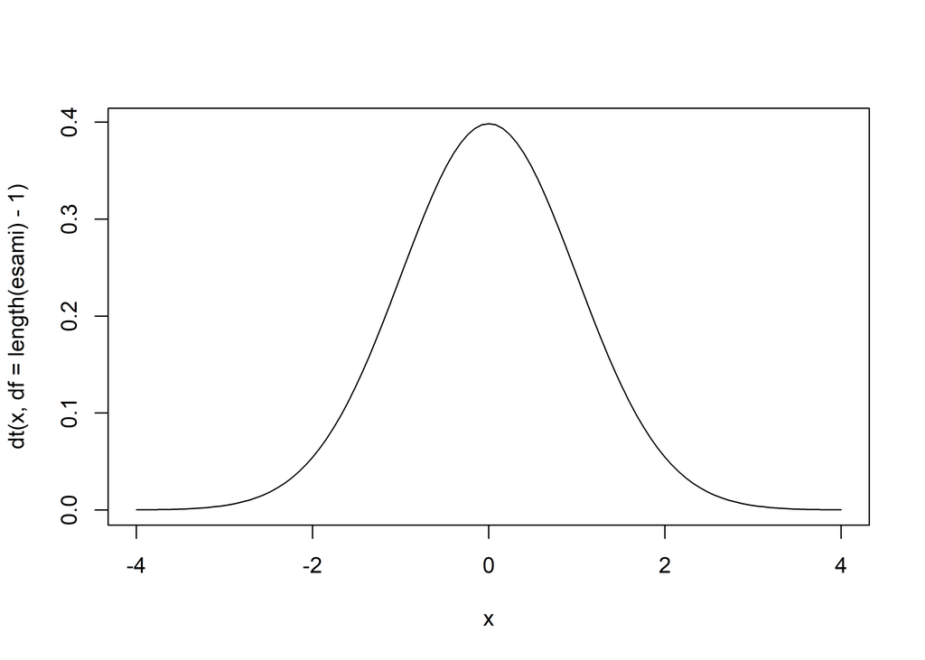

```r
curve(dt(x, df = length(esami) - 1), -4,4)
```

Come vedete il nostro `t` osservato dal t-test molto improbabile considerando l’ipotesi nulla ed infatti il `p-value` è estremamente piccolo.

## Ricodificare variabile

Quando abbaimo un dataframe spesso è utile ricodificare i valori di una colonna in base ad alcune condizioni logiche. Ad esempio, ricodificare l’età in base alla fascia (e.g. maggiore e minore di 18). Per fare questo ci sono diverse funzioni e approcchi:

### `ifelse()`

La funzione `ifelse()` permette di eseguire del codice in modo **condizionale** ovvero in funzione ad una condione logica che quindi restituisce valori `TRUE` e `FALSE`.

Generiamo delle età casuali:

```r
age <- round(runif(30, 15, 70))
age
```

```
##  [1] 63 41 18 40 52 23 22 68 61 65 33 41 16 18 38 61 39 28 16 24 48 40 61 26 61
## [26] 37 56 24 62 19
```

Ora vogliamo creare un vettore di lunghezza 30 con la stringa “minorenne” se il valore di `age` è minore di 18 anni e maggiorenne se il valore è maggiore o uguale a 18:

```r
# test = condizione da testare
# yes = cosa deve succedere se test è TRUE
# no = cosa deve succedere se test è FALSE

ifelse(test = age < 18, yes = "minorenne", no = "maggiorenne")
```

```
##  [1] "maggiorenne" "maggiorenne" "maggiorenne" "maggiorenne" "maggiorenne"
##  [6] "maggiorenne" "maggiorenne" "maggiorenne" "maggiorenne" "maggiorenne"
## [11] "maggiorenne" "maggiorenne" "minorenne"   "maggiorenne" "maggiorenne"
## [16] "maggiorenne" "maggiorenne" "maggiorenne" "minorenne"   "maggiorenne"
## [21] "maggiorenne" "maggiorenne" "maggiorenne" "maggiorenne" "maggiorenne"
## [26] "maggiorenne" "maggiorenne" "maggiorenne" "maggiorenne" "maggiorenne"
```

Se vogliamo più di una condizione possiamo usare più `ifelse()`, uno dentro l’altro:

```r
ifelse(age < 18,
       yes = "minorenne",
       no = ifelse(age > 18 & age < 60,
                   yes = "adulto",
                   no = "anziano"))
```

```
##  [1] "anziano"   "adulto"    "anziano"   "adulto"    "adulto"    "adulto"
##  [7] "adulto"    "anziano"   "anziano"   "anziano"   "adulto"    "adulto"
## [13] "minorenne" "anziano"   "adulto"    "anziano"   "adulto"    "adulto"
## [19] "minorenne" "adulto"    "adulto"    "adulto"    "anziano"   "adulto"
## [25] "anziano"   "adulto"    "adulto"    "adulto"    "anziano"   "adulto"
```

### `case_when()`

Questa funzione può essere utile quando abbiamo tante condizioni. Indicativamente con più di 3 condizioni scrivere tanti `ifelse()` può essere scomodo. In questo caso possiamo usare la funzione `case_when()` dal pacchetto `dplyr`. La sintassi è strana ma molto intuitiva: `test ~ valore` e possiamo mettere più `test` chiaramente separati da una virgola

```r
dplyr::case_when(
    age < 18 ~ "minorenne",
    age >= 18 & age < 60 ~ "adulto",
    age >= 60 ~ "anziano"
    # ...altre condizioni
)
```

```
##  [1] "anziano"   "adulto"    "adulto"    "adulto"    "adulto"    "adulto"
##  [7] "adulto"    "anziano"   "anziano"   "anziano"   "adulto"    "adulto"
## [13] "minorenne" "adulto"    "adulto"    "anziano"   "adulto"    "adulto"
## [19] "minorenne" "adulto"    "adulto"    "adulto"    "anziano"   "adulto"
## [25] "anziano"   "adulto"    "adulto"    "adulto"    "anziano"   "adulto"
```

## 1.12

Leggiamo i dati:

```r
dat <- readxl::read_xls(path = "../data/pazienti.xls")
```

Vediamo i quartili:

```r
# con summary ci vengono già calcolati
summary(dat$ansia)
```

```
##    Min. 1st Qu.  Median    Mean 3rd Qu.    Max.
##   0.700   3.425   4.350   4.160   5.400   6.700
```

Il 2 quartile è in realtà la mediana, quindi possiamo calcolarlo con la funzione `median()`:

```r
median(dat$ansia) # 2 quartile
```

```
## [1] 4.35
```

Il modo più generale e versatile però è usare la funzione `quantile()` che permette di ottenere qualsiasi quantile e non solo i quartili. Otteniamo il 25, 50 e 75 percentile ovvero il primo, secondo e terzo quartile:

```r
quantile(dat$ansia, probs = c(0.25, 0.5, 0.75))
```

```
##   25%   50%   75%
## 3.425 4.350 5.400
```

Possiamo ottenere i quantili anche per variabili ordinali. Prima però dobbiamo dire ad R che le etichette della variabile sono in realtà in ordine:

```r
# fattore normale
factor(dat$cl.sociale)
```

```
##  [1] Bassa Media Media Bassa Bassa Media Alta  Bassa Media Bassa Alta  Bassa
## [13] Media Alta  Bassa Media Media Bassa Alta  Bassa Media Bassa Media Bassa
## [25] Bassa Bassa Media Bassa Alta  Alta
## Levels: Alta Bassa Media
```

```r
# fattore ordinato
ordered(dat$cl.sociale, levels = c("Bassa", "Media", "Alta"))
```

```
##  [1] Bassa Media Media Bassa Bassa Media Alta  Bassa Media Bassa Alta  Bassa
## [13] Media Alta  Bassa Media Media Bassa Alta  Bassa Media Bassa Media Bassa
## [25] Bassa Bassa Media Bassa Alta  Alta
## Levels: Bassa < Media < Alta
```

```r
# fattore ordinato usando il comando factor
factor(dat$cl.sociale,
       levels = c("Bassa", "Media", "Alta"),
       ordered = TRUE)
```

```
##  [1] Bassa Media Media Bassa Bassa Media Alta  Bassa Media Bassa Alta  Bassa
## [13] Media Alta  Bassa Media Media Bassa Alta  Bassa Media Bassa Media Bassa
## [25] Bassa Bassa Media Bassa Alta  Alta
## Levels: Bassa < Media < Alta
```

Per ottenere i quantili poi dobbiamo cambiare il tipo di algoritmo, in particolare il `type = 1`:

```r
cl_sociale_ord <- ordered(dat$cl.sociale, levels = c("Bassa", "Media", "Alta"))

quantile(cl_sociale_ord, probs = c(0.25, 0.5, 0.75), type = 1)
```

```
##   25%   50%   75%
## Bassa Media Media
## Levels: Bassa < Media < Alta
```

Ogni volta che avete un dubbio, leggete la documentazione delle funzioni R ed i messaggi di errore/warning. In questo caso sono molto utili per capire cosa dobbiamo fare:

```r
# fattore non ordinato
cl_sociale_fac <- factor(dat$cl.sociale)
quantile(cl_sociale_fac, probs = c(0.25, 0.5, 0.75))
```

```
## Error in quantile.default(cl_sociale_fac, probs = c(0.25, 0.5, 0.75)): (unordered) factors are not allowed
```

Il rango percentile invece è la percentuale di valori minori o uguali ad un dato valore $x_i$. Quindi può essere visto come “speculare” al percentile. Facciamo un esempio con la mediana:

- il rango percentile della mediana è 50% (o 0.5)
- mentre il valore associato al 50% rango percentile è la mediana

Con la funzione `quantile()` noi chiediamo quale valore è associato ad un certo rango percentile (argomento `probs =`) mentre se calcoliamo manualmente la quantità di valori uguali o inferiori ad un dato valore allora stiamo calcolando il rango percentile.

Ad esempio, calcoliamo il rango percentile di 39 (magari ci sono funzioni che lo fanno già direttamente):

```r
sort(dat$eta) # ordinare
```

```
##  [1] 21 29 32 35 36 36 37 39 41 42 43 44 45 45 47 48 48 50 52 53 54 55 56 57 57
## [26] 58 63 65 67 70
```

```r
mean(sort(dat$eta) <= 39)
```

```
## [1] 0.2666667
```

Lo stesso principio si può usare con distribuzioni teoriche le quali sono già implementate in R. Tutte le distribuzioni disponibili hanno le funzioni `d`, `p`, `q`, `r` che permettono di calcolare o generare dati. Ad esempio:

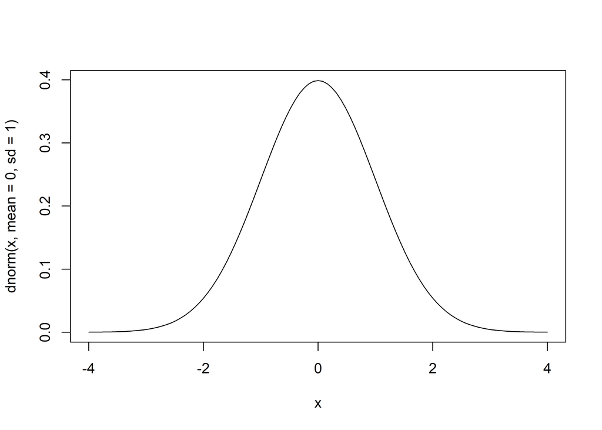

```r
curve(dnorm(x, mean = 0, sd = 1), -4, 4)
```

il rango percentile (la percentuale/probabilità cumulata) si calcola con il comando `p`. Nel caso della normale:

```r
# q = quantile su cui calcolare il rango percentile
# mean = media della distribuzione normale
# sd = deviazione standard della distribuzione normale

pnorm(q = 0, mean = 0, sd = 1)
```

```
## [1] 0.5
```

il quantile associato ad un certo rango percentile si calcola con il comando `q`:

```r
# p = probabilità comulata associata ad un certo quantile (aka rango percentile)
# mean = media della distribuzione normale
# sd = deviazione standard della distribuzione normale

qnorm(p = 0.5, mean = 0, sd = 1)
```

```
## [1] 0
```

## Varianza, devianza e deviazione standard

La varianza e la deviazione standard sono 2 indici di dispersione molto utilizzati perchè indicano quanto i valori di una distribuzione di dati sono dispersi rispetto alla media.

Per capire è utile scomporre le formule. La devianza $SS$ è la somma degli scarti alla media. Gli scarti sono le differenze di ogni valore della distribuzione dalla sua media (si utilizza $n - 1$ quando si stima la varianza campionaria mentre solo $n$ per la varianza della popolazione)

$$SS = \sum_{i = 1}^n (x_i - \bar x)^2$$

La varianza $\sigma^2$ è la media degli scarti dalla media. Quindi è semplicemente la devianza divisa per il numero di elementi:

$$\sigma^2 = \frac{\sum_{i = 1}^n (x_i - \bar x)^2}{n - 1} =
\frac{SS}{n-1}$$
La deviazione standard infine non è altro che la radice quadrata della varianza.

In R possiamo calcolarle con le funzioni `var()` e `sd()` e la devianza semplicemente adattando la formula:

```r
# devianza. somma degli scarti dalla media al quadrata
SS <- sum((dat$eta - mean(dat$eta))^2)
SS
```

```
## [1] 3957.5
```

```r
# varianza
SS / (length(dat$eta) - 1)
```

```
## [1] 136.4655
```

```r
var(dat$eta)
```

```
## [1] 136.4655
```

```r
# deviazione standard
sqrt(SS / (length(dat$eta) - 1))
```

```
## [1] 11.68185
```

```r
sd(dat$eta)
```

```
## [1] 11.68185
```

## Moda

La **moda** invece è l’elemento/i di una distribuzione associato/i alla frequenza massima. Al contrario di media e mediana ci possono essere più mode. In questo caso la distribuzione viene definita multimodale.

Vediamo la distribuzione:

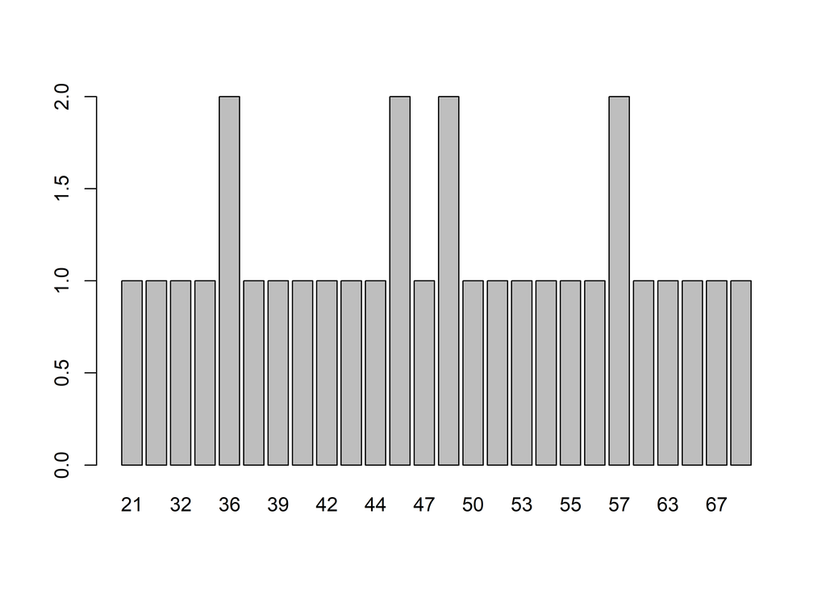

```r
barplot(table(dat$eta)) # visualizziamo le 4 mode
```

Vediamo se corrispondono:

```r
ADati::moda(dat$cl.sociale)
```

```
## $moda
## [1] "Bassa"
##
## $frequenza.modale
## [1] 14
```

```r
ADati::moda(dat$eta)
```

```
## $moda
## [1] "36" "45" "48" "57"
##
## $frequenza.modale
## [1] 2
```

## Boxplot

Il boxplot è una delle rappresentazioni grafiche più semplici ma potenti che ci siano. Fornisce tante informazioni su una distribuzione di valori numerici come:

- i quartili
- lo scarto interquartile ($IRQ$)
- eventuali outlier

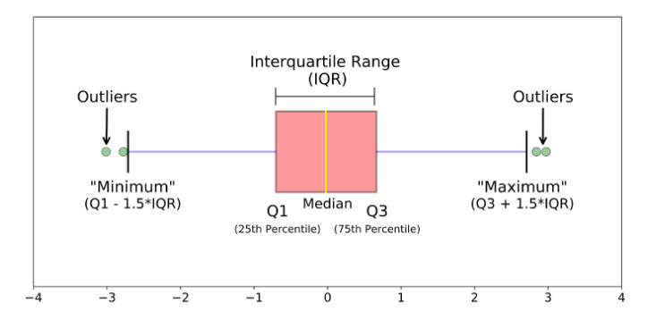

Elementi principali di un Boxplot. Fonte https://towardsdatascience.com/understanding-boxplots-5e2df7bcbd51

Possiamo crearlo con il comando `boxplot()`:

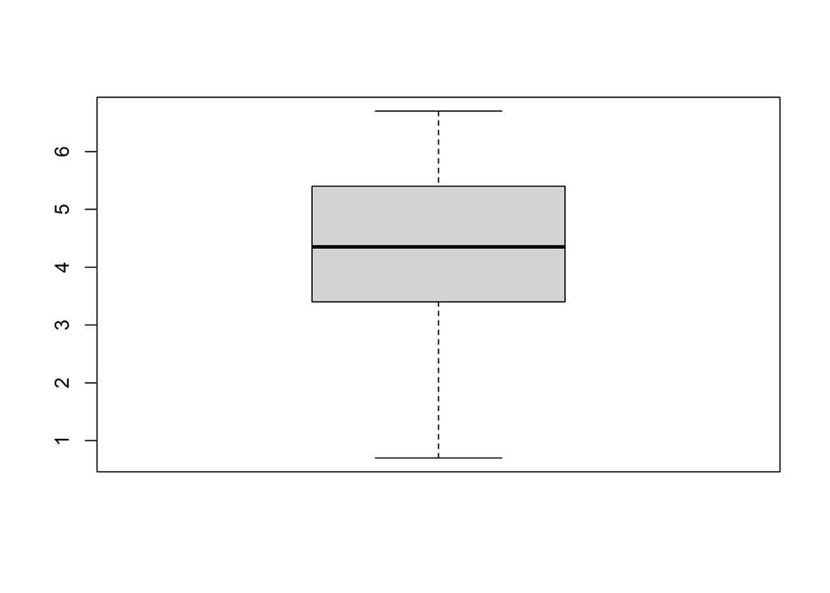

```r
boxplot(dat$ansia)
```

Un trucco per capire intuitivamente il boxplot è immaginarlo come un istogramma dall’alto. Infatti come l’istogramma ci da un’idea della forma della distribuzione ma con molte più informazioni:

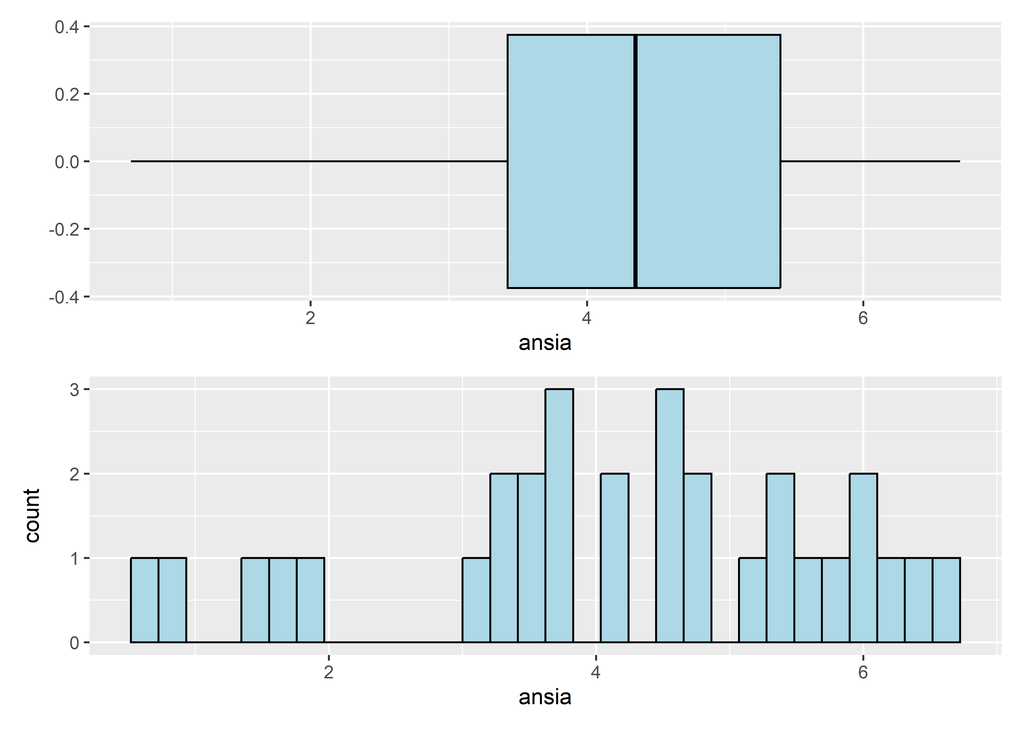

```r
histp <- ggplot(dat) +
    geom_histogram(aes(x = ansia),
                   bins = 30,
                   fill = "lightblue",
                   col = "black")
boxp <- ggplot(dat) +
    geom_boxplot(aes(x = ansia),
                 fill = "lightblue",
                 col = "black")
boxp / histp # patchwork
```

[^1]: https://www.frontiersin.org/articles/10.3389/fpsyg.2013.00863/full